# 06. 모델의 성능 평가

- 모델 성능을 판단할 때 어떤 측정항목을 조사할지 결정하는 것이 중요
- 특정 모델 매개변수가 경험적으로 최적화되고 주요 성능 지표를 사용하여 최상의 하위 모델을 선택
- 잘못된 측정항목을 선택하면 의도하지 않은 결과가 발생
  - 예를 들어, 회귀 모델의 두 가지 일반적인 측정항목은 RMSE(제곱평균제곱근)와 결정계수($R^2$)
  - 전자는 정확도를 측정 하고 후자는 실제값과 적합값의 상관관계를 측정.
- RMSE에 최적화된 모델은 가변성이 더 크지만 결과 범위 전체에 걸쳐 상대적으로 균일한 정확도를 가짐

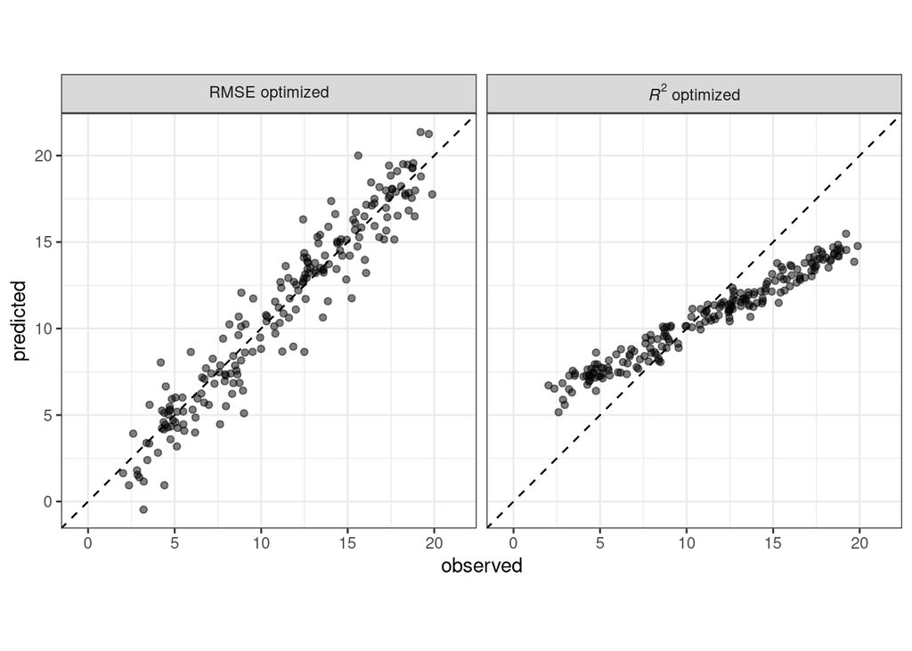

```r
library(tidyverse)
library(tidymodels)
ggplot2::theme_set(theme_bw())
tidymodels_prefer()
```

```r
data(ames)
ames <- mutate(ames, Sale_Price = log10(Sale_Price))
```

```r
set.seed(502)
ames_split <- initial_split(ames, prop = 0.80, strata = Sale_Price)
ames_train <- training(ames_split)
ames_test  <-  testing(ames_split)
```

## 06.01. 성능 지표와 추론

- 특정 모델의 성능은 모델이 어떻게 사용되는지에 따라 달라짐.
  - **추론 모델은 주로 관계를 이해하는 데 사용되며 일반적으로 모델을 정의하는 확률 분포 및 기타 생성적 특성의 선택(및 타당성)을 강조**
  - **예측에 사용되는 모델의 경우 예측 강도가 가장 중요하며, 기본 통계 품질에 대한 기타 고려 사항은 덜 중요**
- **예측 정확도는 일반적으로 우리의 예측이 관찰된 데이터에 얼마나 가까운지, 즉 실제 결과에 대한 모델 예측의 충실도에 따라 결정**

## 06.02. 회귀모델 평가 지표

- 전처리 정의

```r
ames_rec <- recipe(Sale_Price ~ Neighborhood + Gr_Liv_Area + Year_Built + Bldg_Type +
           Latitude + Longitude, data = ames_train) %>%
  step_log(Gr_Liv_Area, base = 10) %>%
  step_other(Neighborhood, threshold = 0.01) %>%
  step_dummy(all_nominal_predictors()) %>%
  step_interact( ~ Gr_Liv_Area:starts_with("Bldg_Type_")) %>%
  step_ns(Latitude, Longitude, deg_free = 20)
```

- 선형회귀모델 정의

```r
lm_model <- linear_reg() %>% set_engine("lm")
```

- 워크플로 생성

```r
lm_wflow <- workflow() %>%
  add_model(lm_model) %>%
  add_recipe(ames_rec)
```

- 모델 적합 및 예측

```r
lm_fit <- fit(lm_wflow, ames_train)
```

```r
ames_test_res <- predict(lm_fit, new_data = ames_test %>% select(-Sale_Price))
ames_test_res <- bind_cols(ames_test_res, ames_test %>% select(Sale_Price))
ames_test_res %>% head()
```

A tibble: 6 × 2

| .pred <dbl> | Sale_Price <dbl> |
| --- | --- |
| 5.068004 | 5.021189 |
| 5.308006 | 5.387390 |
| 5.283059 | 5.278525 |
| 5.334702 | 5.282169 |
| 5.300226 | 5.276462 |
| 5.244411 | 5.256237 |

- 실제값 vs 예측값 산점도

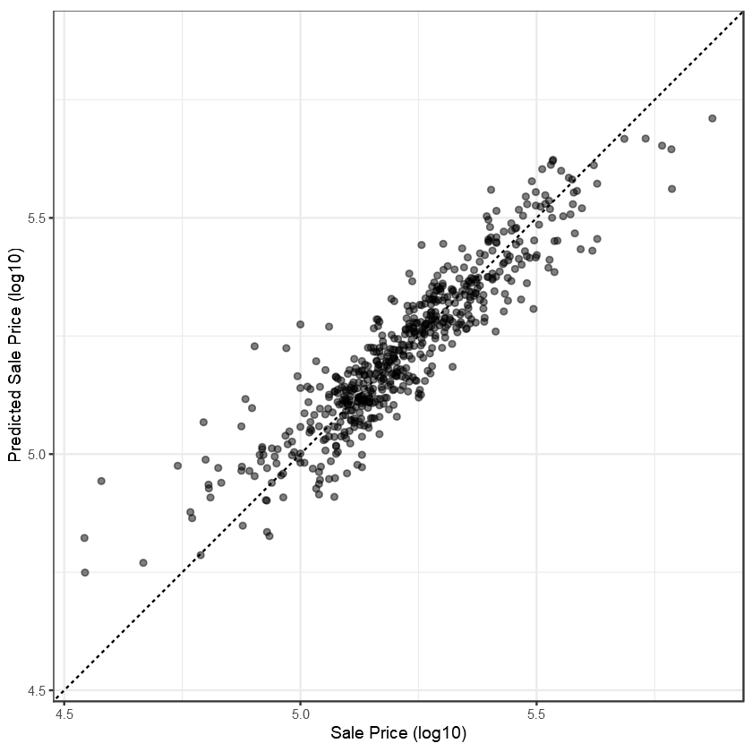

```r
ggplot(ames_test_res, aes(x = Sale_Price, y = .pred)) +
    geom_abline(lty = 2) +
    geom_point(alpha = 0.5) +
    labs(y = "Predicted Sale Price (log10)", x = "Sale Price (log10)") +
    coord_obs_pred()
```

- 모델 평가

#### `metric_set()` : 평가 척도 지정

- **`rmse()` : RMSE**
- **`rsq()` : $R^2$**
- **`mae()` : MAE**

```r
ames_metrics <- metric_set(rmse, rsq, mae)
ames_metrics(ames_test_res, truth = Sale_Price, estimate = .pred)
```

A tibble: 3 × 3

| .metric <chr> | .estimator <chr> | .estimate <dbl> |
| --- | --- | --- |
| rmse | standard | 0.07362974 |
| rsq | standard | 0.83593999 |
| mae | standard | 0.05488583 |

## 06.03. 이진분류모델 평가 지표

#### `conf_mat()` : 혼동행렬

#### `accuracy()` : 정확도

#### `mcc()` : [Mattews correlation coefficient (벡터간 상관계수)](https://choice-life.tistory.com/82)

#### `f_meas` : F1-score

- Matthews (MCC) 상관 계수와 F1 점수는 모두 혼동 행렬을 요약하지만, **Positive와 Negative 모두의 품질을 측정하는 `mcc()` 에 비해, `f_meas()` 는 관심 있는 이벤트인 Positive Class를 강조**

```r
data(two_class_example)
two_class_example %>% head()
```

A data.frame: 6 × 4

|  | truth <fct> | Class1 <dbl> | Class2 <dbl> | predicted <fct> |
| --- | --- | --- | --- | --- |
| 1 | Class2 | 0.003589243 | 0.9964107574 | Class2 |
| 2 | Class1 | 0.678621054 | 0.3213789460 | Class1 |
| 3 | Class2 | 0.110893522 | 0.8891064779 | Class2 |
| 4 | Class1 | 0.735161703 | 0.2648382969 | Class1 |
| 5 | Class2 | 0.016239960 | 0.9837600397 | Class2 |
| 6 | Class1 | 0.999275071 | 0.0007249286 | Class1 |

```r
conf_mat(two_class_example, truth = truth, estimate = predicted)
accuracy(two_class_example, truth, predicted)
mcc(two_class_example, truth, predicted)
f_meas(two_class_example, truth, predicted)
```

```
          Truth
Prediction Class1 Class2
    Class1    227     50
    Class2     31    192
```

A tibble: 1 × 3

| .metric <chr> | .estimator <chr> | .estimate <dbl> |
| --- | --- | --- |
| accuracy | binary | 0.838 |

A tibble: 1 × 3

| .metric <chr> | .estimator <chr> | .estimate <dbl> |
| --- | --- | --- |
| mcc | binary | 0.6768476 |

A tibble: 1 × 3

| .metric <chr> | .estimator <chr> | .estimate <dbl> |
| --- | --- | --- |
| f_meas | binary | 0.8485981 |

```r
classification_metrics <- metric_set(accuracy, mcc, f_meas)
classification_metrics(two_class_example, truth = truth, estimate = predicted)
```

A tibble: 3 × 3

| .metric <chr> | .estimator <chr> | .estimate <dbl> |
| --- | --- | --- |
| accuracy | binary | 0.8380000 |
| mcc | binary | 0.6768476 |
| f_meas | binary | 0.8485981 |

#### `roc_auc()` : AUC값 계산

```r
two_class_curve <- roc_curve(two_class_example, truth, Class1)
two_class_curve %>% head()
```

A roc_df: 6 × 3

| .threshold <dbl> | specificity <dbl> | sensitivity <dbl> |
| --- | --- | --- |
| -Inf | 0.000000000 | 1 |
| 1.794262e-07 | 0.000000000 | 1 |
| 4.503065e-06 | 0.004132231 | 1 |
| 5.813991e-06 | 0.008264463 | 1 |
| 5.922113e-06 | 0.012396694 | 1 |
| 1.216854e-05 | 0.016528926 | 1 |

A tibble: 1 × 3

| .metric <chr> | .estimator <chr> | .estimate <dbl> |
| --- | --- | --- |
| roc_auc | binary | 0.9393139 |

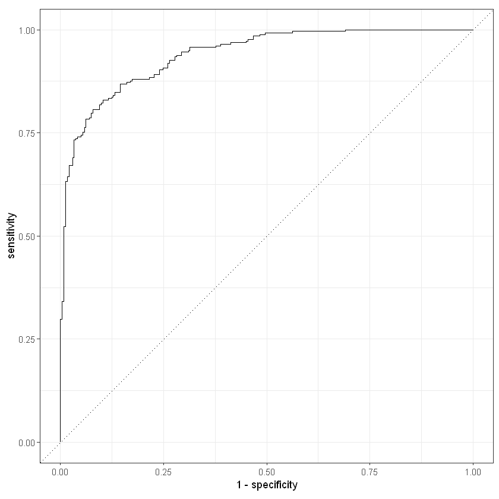

```r
roc_auc(two_class_example, truth, Class1)
autoplot(two_class_curve)
```

#### `gain_curve()` : 분류모델을 사용하여 얻게되는 이득

- **이익도표 (Gain Chart)**
  1. 분류모델을 이용하여 $x_i$가 주어졌을 때, $y_i=1$인 확률을 계산하고 이 확률값으로 데이터를 오름차순으로 정렬
  2. 데이터를 $n$등분 (일반적으로 10등분)
  3. Gain 통계량 계산 :
  - $y_i=1$인 데이터의 개수가 $N_k$일 때, 구간별 $y_i=1$인 데이터 빈도수 $P_k=1, \dots ,10$을 계산
  - 각 구간별 Gain 통계량 $IG_k$를 계산

    $$IG_k = \frac{P_k}{N_k},\;\;k=1, \dots, K$$
  - 상위 랭크에서부터 구간별 Gain 통계량 $IG_k$를 누적

    $$G_k = \sum^K_{j=1}IG_j$$
- **Gain Curve : 구간 $k$에 대한 Gain 통계량 $G_k$를 커브로 표현**
- Gain 통계량은 해당 구간의 데이터 개수 대비 $y_i=1$인 빈도수의 비를 나타냄
- 상위 랭크에서 이 값이 클수록 분류 모델의 성능이 높다는 것을 의미

  $\rightarrow$ 탐색하고 싶은 클래스를 찾는데 있어서 분류모델을 사용하는 것에 대한 이득이 있다는 것을 의미

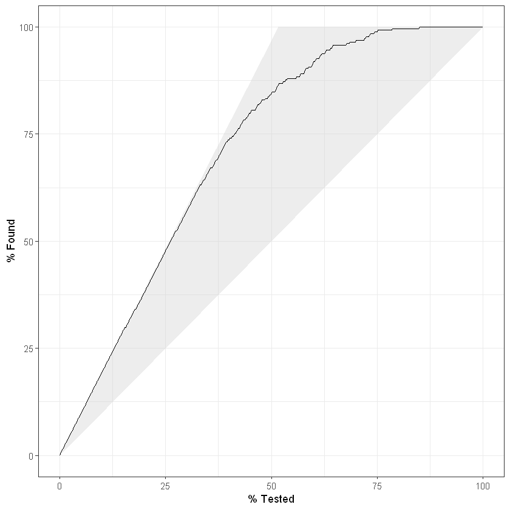

```r
two_class_curve2 <- gain_curve(two_class_example, truth, Class1)
autoplot(two_class_curve2)
```

- Gain 차트 활용 예시 :
  - 마케팅에서 어떤 고객을 중점적으로 마케팅 작업을 해야 하는지 탐색
  - 아래의 그림과 같은 커브를 얻었다면, 이미 3등급 내에서 Gain을 0.9를 달성하므로, 전체고객을 다 상대할 필요 없이 상위 30%만 타겟으로 하여 효율적인 마케팅
- 몇 등급까지 봐아하는지는 분석자의 주관적 판단
- 여러 Gain 커브가 교차가 된다면 어떤 모델을 선택해야 하는지 판단이 어려움

[figure not shown]

#### `lift_curve()` : 향상도 (분류모델을 사용하지 않았을 때보다, 사용한 경우 더 이익이 되는정도)

- **향상도 (Lift)**
  1. 분류모델을 이용하여 $x_i$가 주어졌을 때 $y_i=1$인 확률을 계산하고 이 확률값으로 데이터를 오름차순으로 정렬
  2. 데이터를 $n$등분
  3. Lift 통계량 계산 :
  - Lift 통계량 : 해당 구간에서 모델을 사용하지 않았을 경우보다 모형을 사용했을 때 얻을 수 있는 정분류율의 증가분
    - 해당 구간에서 Lift 통계량이 1보다 커야 의미가 있고, 그 값이 클수록 분류 모델로 얻는 이득이 크다는 것을 의미
  - 각 구간별 데이터 수 $N_k$와 $y_i=1$인 데이터 빈도수 (개수) $P_k,\;k=1, \dots, 10$를 계산
  - 각 구간별 반응률 $R_k$를 계산

    $$R_k = \frac{P_k}{N_k},\;k=1, \dots, K=IG_k$$
  - Baseline Lift 통계량 $BL$ 계산 : $BL$은 모델을 사용하지 않았을 때, $x_i$가 주어진 경우 $y_i=1$인 조건부 확률
    - $x_i$가 주어진 경우 0과 1사이에서 난수를 생성하여 그 값이 $BL$보다 작은 경우, $y_i=1$, 큰 경우 $y_i=0$으로 예측함을 의미 (Random Model)

    $$BL = \frac{|\{i:y_i =1\}|}{n}$$
  - Lift 통계량

    $$L_k = \frac{R_k}{BL}$$
- **Lift Curve : 구간 $k$에 대한 Lift 통계량 $L_k$를 커브로 표현**
  - **Lift 값이 높은 곳에서 빠르게 감소할수록 상위 구간에서 중요 클래스 ($y_i=1$)를 정확하게 예측했다는 것이므로 좋은 모형이라고 판단**

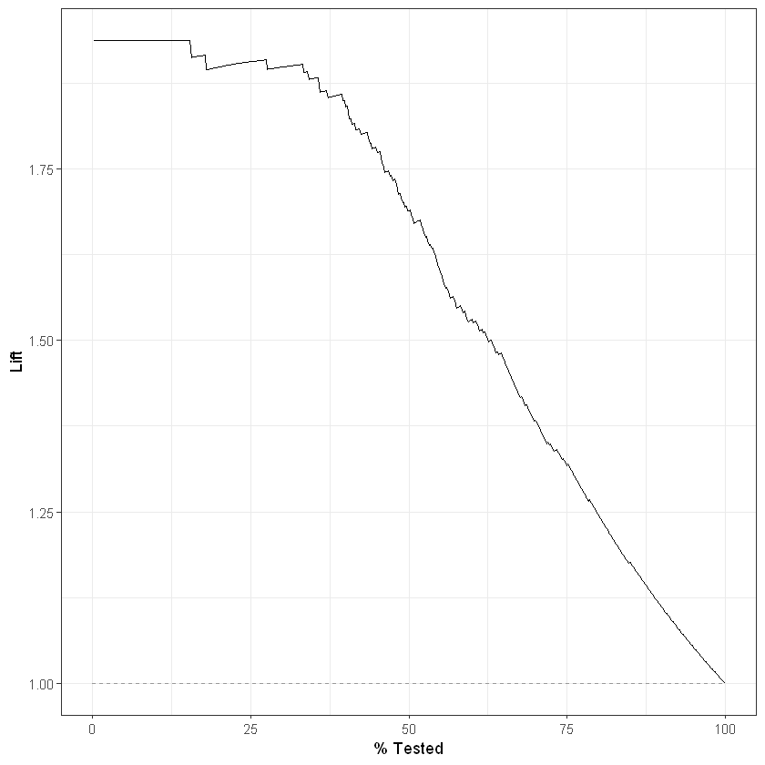

```r
two_class_curve3 <- lift_curve(two_class_example, truth, Class1)
autoplot(two_class_curve3)
```

- Lift 커브 활용 예시 :
  - 마케팅에서 어떤 고객을 중점적으로 마케팅 작업을 해야 하는지 탐색
  - 아래의 그림과 같은 커브를 얻었다면, 1보다 큰 등급은 상대적으로 높은 등급이라고 한다면 1, 2 등급에 대응하는 고객을 대상으로 마케팅을 수행
- 몇 등급까지 봐아하는지는 분석자의 주관적 판단
- 여러 Lift 커브가 교차가 된다면 어떤 모델을 선택해야 하는지 판단이 어려움

[figure not shown]

#### `pr_curve()` : 정밀도-재현율 커브 (Precision-Recall Curve)

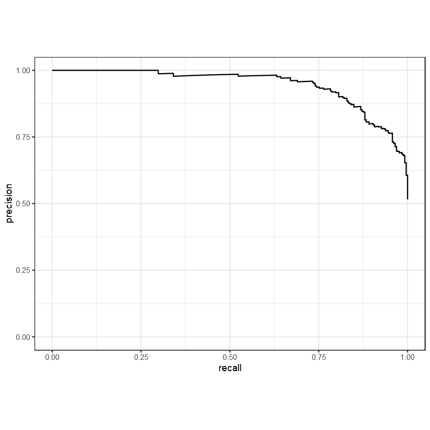

```r
two_class_curve4 <- pr_curve(two_class_example, truth, Class1)
autoplot(two_class_curve4)
```

## 06.04. 다항분류모델 평가 지표

https://rython.tistory.com/14

```r
data(hpc_cv)
hpc_cv %>% head
```

A data.frame: 6 × 7

|  | obs <fct> | pred <fct> | VF <dbl> | F <dbl> | M <dbl> | L <dbl> | Resample <chr> |
| --- | --- | --- | --- | --- | --- | --- | --- |
| 1 | VF | VF | 0.9136340 | 0.07786694 | 0.008479147 | 1.991225e-05 | Fold01 |
| 2 | VF | VF | 0.9380672 | 0.05710623 | 0.004816447 | 1.011557e-05 | Fold01 |
| 3 | VF | VF | 0.9473710 | 0.04946767 | 0.003156287 | 4.999849e-06 | Fold01 |
| 4 | VF | VF | 0.9289077 | 0.06528949 | 0.005787179 | 1.564496e-05 | Fold01 |
| 5 | VF | VF | 0.9418764 | 0.05430830 | 0.003808013 | 7.294581e-06 | Fold01 |
| 6 | VF | VF | 0.9510978 | 0.04618223 | 0.002716177 | 3.841455e-06 | Fold01 |

```r
accuracy(hpc_cv, obs, pred)
mcc(hpc_cv, obs, pred)
```

A tibble: 1 × 3

| .metric <chr> | .estimator <chr> | .estimate <dbl> |
| --- | --- | --- |
| accuracy | multiclass | 0.7086819 |

A tibble: 1 × 3

| .metric <chr> | .estimator <chr> | .estimate <dbl> |
| --- | --- | --- |
| mcc | multiclass | 0.5153081 |

#### Micro Average

- **Micro Average는 각각의 TP, FN, FP, TN값들을 모두 합친 total TP, total FN, total FP, total TN값들을 이용해 계산**

$\text{TP}_{\text{total}}=\sum^{c}_{i=1}\text{TP}_{i}\\\text{FN}_{\text{total}}=\sum^{c}_{i=1}\text{FN}_{i}\\\text{FP}_{\text{total}}=\sum^{c}_{i=1}\text{FP}_{i}\\\text{TN}_{\text{total}}=\sum^{c}_{i=1}\text{TN}_{i}$

- Accuracy, Sensitivity, Specificity, False Alarm rate, Precision, F-score들을 total 값들을 이용해서 계산 $\text{Accuracy}=\text{Precision}=\text{Sensitivity}=\text{F1 score}$ 가 성립

#### Macro Average

$\text{Sensitivity}=\frac{1}{c}\sum^{c}_{i=1}\text{Sensitivity}_{i}=\frac{1}{c}\sum^{c}_{i=1}\frac{\text{TP}_{i}}{\text{TP}_{i}+\text{FN}_{i}}$

#### Macro Weighted Average

- **그냥 평균을 계산하는 것이 아니라 각 class에 해당하는 관측값 개수에 가중치를 주어 평균을 구한 것**
- 전체 data 중 class i에 속하는 data 개수의 비율을 p(i)로 생각한다면 Sensitivity의 식은 $\text{Sensitivity}=\sum^{c}_{i=1}p(i)\text{Sensitivity}_{i}=\sum^{c}_{i=1}p(i)\frac{\text{TP}_{i}}{\text{TP}_{i}+\text{FN}_{i}}$
- 각 클래스의 분포

```r
(class_totals <- count(hpc_cv, obs, name = "totals") %>%
    mutate(class_wts = totals / sum(totals)))
```

A data.frame: 4 × 3

| obs <fct> | totals <int> | class_wts <dbl> |
| --- | --- | --- |
| VF | 1769 | 0.51023940 |
| F | 1078 | 0.31093164 |
| M | 412 | 0.11883473 |
| L | 208 | 0.05999423 |

- 각 클래스별 정확도

```r
cell_counts <- hpc_cv %>%
    group_by(obs, pred) %>%
    count() %>%
    ungroup()

cell_counts
```

A tibble: 16 × 3

| obs <fct> | pred <fct> | n <int> |
| --- | --- | --- |
| VF | VF | 1620 |
| VF | F | 141 |
| VF | M | 6 |
| VF | L | 2 |
| F | VF | 371 |
| F | F | 647 |
| F | M | 24 |
| F | L | 36 |
| M | VF | 64 |
| M | F | 219 |
| M | M | 79 |
| M | L | 50 |
| L | VF | 9 |
| L | F | 60 |
| L | M | 28 |
| L | L | 111 |

```r
(one_versus_all <- cell_counts %>%
    filter(obs == pred) %>%
    full_join(class_totals, by = "obs") %>%
    mutate(sens = n / totals))
```

A tibble: 4 × 6

| obs <fct> | pred <fct> | n <int> | totals <int> | class_wts <dbl> | sens <dbl> |
| --- | --- | --- | --- | --- | --- |
| VF | VF | 1620 | 1769 | 0.51023940 | 0.9157716 |
| F | F | 647 | 1078 | 0.31093164 | 0.6001855 |
| M | M | 79 | 412 | 0.11883473 | 0.1917476 |
| L | L | 111 | 208 | 0.05999423 | 0.5336538 |

- macro : 각 클래스별 정확도 평균
- macro_wts : 각 관측값 수의 수를 가중치로 가지는 각 클래스별 정확도 가중 평균
- micro : 전체 데이터의 정분류율

```r
one_versus_all %>%
  summarize(
    macro = mean(sens),
    macro_wts = weighted.mean(sens, class_wts),
    micro = sum(n) / sum(totals))
```

A tibble: 1 × 3

| macro <dbl> | macro_wts <dbl> | micro <dbl> |
| --- | --- | --- |
| 0.5603396 | 0.7086819 | 0.7086819 |

#### `sensitivity()` : 민감도

- `estimator` : `macro` / `macro_weighted` / `micro`

```r
sensitivity(hpc_cv, obs, pred, estimator = "macro")
sensitivity(hpc_cv, obs, pred, estimator = "macro_weighted")
sensitivity(hpc_cv, obs, pred, estimator = "micro")
```

A tibble: 1 × 3

| .metric <chr> | .estimator <chr> | .estimate <dbl> |
| --- | --- | --- |
| sensitivity | macro | 0.5603396 |

A tibble: 1 × 3

| .metric <chr> | .estimator <chr> | .estimate <dbl> |
| --- | --- | --- |
| sensitivity | macro_weighted | 0.7086819 |

A tibble: 1 × 3

| .metric <chr> | .estimator <chr> | .estimate <dbl> |
| --- | --- | --- |
| sensitivity | micro | 0.7086819 |

#### 다중 클래스 ROC / AUC

```r
roc_auc(hpc_cv, obs, VF, F, M, L, estimator = "macro_weighted")
roc_auc(hpc_cv, obs, VF, F, M, L, estimator = "macro")
roc_auc(hpc_cv, obs, VF, F, M, L)
```

A tibble: 1 × 3

| .metric <chr> | .estimator <chr> | .estimate <dbl> |
| --- | --- | --- |
| roc_auc | macro_weighted | 0.8683179 |

A tibble: 1 × 3

| .metric <chr> | .estimator <chr> | .estimate <dbl> |
| --- | --- | --- |
| roc_auc | macro | 0.8692636 |

A tibble: 1 × 3

| .metric <chr> | .estimator <chr> | .estimate <dbl> |
| --- | --- | --- |
| roc_auc | hand_till | 0.8288675 |

```r
hpc_cv %>%
  group_by(Resample) %>%
  accuracy(obs, pred)
```

A tibble: 10 × 4

| Resample <chr> | .metric <chr> | .estimator <chr> | .estimate <dbl> |
| --- | --- | --- | --- |
| Fold01 | accuracy | multiclass | 0.7262248 |
| Fold02 | accuracy | multiclass | 0.7118156 |
| Fold03 | accuracy | multiclass | 0.7579251 |
| Fold04 | accuracy | multiclass | 0.7118156 |
| Fold05 | accuracy | multiclass | 0.7118156 |
| Fold06 | accuracy | multiclass | 0.6974063 |
| Fold07 | accuracy | multiclass | 0.6753623 |
| Fold08 | accuracy | multiclass | 0.7212644 |
| Fold09 | accuracy | multiclass | 0.6734104 |
| Fold10 | accuracy | multiclass | 0.6994220 |

- 각 클래스-Fold별 ROC 커브

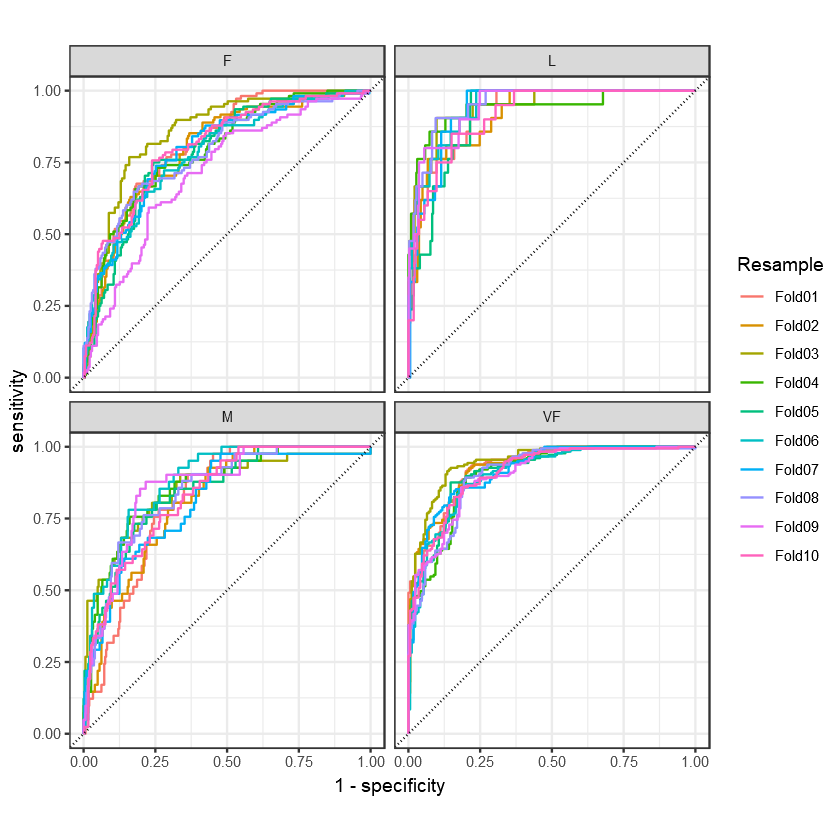

```r
hpc_cv %>%
  group_by(Resample) %>%
  roc_curve(obs, VF, F, M, L) %>%
  autoplot()
```